# Study Correlations

Gerard Temprano Sagrera

```r
bio <- read.xlsx("C://Users/Gerard/Desktop/AAA/RNAseq/20221115_Datos Pacientes.xlsx")
bio <- bio[2:nrow(bio),]
bio <- bio %>% remove_rownames %>% column_to_rownames(var="Muestra")
table(bio$Status)
```

```
##
##    Case Control
##      97      44
```

```r
tec <- read.xlsx("C://Users/Gerard/Desktop/AAA/RNAseq/Tables/Technical_Complete.xlsx")
tec <- tec %>% remove_rownames %>% column_to_rownames(var="Seq_ID")
```

### Fix columns:

```r
# Select columns:
bio2 <- bio[,c("Status","SEXO","age","TIPOANEURISMA","symptomatic","Height_cm","Weight_Kg","Smoking","other_aneurysm",
                "aortc_diameter_mm")]

names(bio2) <- c("STATUS","SEX","AGE","TYPE","SYMPTOMS","HEIGHT","WEIGHT","SMOKING","O.ANEURYSM","DIAMETER")

# Transform to numeric:
bio2$STATUS <- as.numeric(as.factor(bio2$STATUS))
bio2$SEX <- as.numeric(bio2$SEX)
bio2$TYPE <- as.numeric(bio2$TYPE)
bio2$SYMPTOMS <- as.numeric(bio2$SYMPTOMS)
bio2$SMOKING <- as.numeric(bio2$SMOKING)
bio2$O.ANEURYSM <- as.numeric(bio2$O.ANEURYSM)
```

```r
tec2 <-  tec[ ,!names(tec) %in% c("SampleID","Case")]

names(tec2) <- c("INDEX.i7","INDEX.i5","FC","LANE","PLATE","RIN","DV200","QUBIT","GC_MEAN")

# Transform to numeric:
tec2$INDEX.i5 <- as.numeric(as.factor(tec2$INDEX.i5))
tec2$INDEX.i7 <- as.numeric(as.factor(tec2$INDEX.i7))
tec2$FC <- as.numeric(as.factor(tec2$FC))
tec2$LANE <- as.numeric(as.factor(tec2$LANE))
```

```r
b.cases <- bio2[bio2$STATUS == "1",]
b.controls <- bio2[bio2$STATUS == "2",]

t.cases <- tec2[1:97,]
t.controls <- tec2[98:nrow(tec2),]
```

1. Only sample, status, sex and age have no NAs.
2. Cases only: Type, Symptomatic, Height, Weight, PAD, Other Aneurysm, Aortic Diameter, Leucocytes, Neutrophiles, Limphocytes, Monocytes, Platalets, Hb, RDW.
3. Controls only: Pathology.

# Correlation study:

## ALL:

```r
# Remove pathology (only available in controls):
bio2 <- bio2[ ,!names(bio2) %in% c("Pathology")]
```

### Merge all covariates:

```r
all <- merge(bio2, tec2, by = 0)
all <- all %>% remove_rownames %>% column_to_rownames(var="Row.names")
```

```r
M <- cor(all, use = "pairwise.complete.obs")
testRes <- cor.mtest(all, conf.level = 0.95)

M[is.na(M)] <- 0
testRes$p[is.na(testRes$p)] <- 1

png(file = "C://Users/Gerard/Desktop/AAA/RNAseq/Plots/Correlations/Correlation_Plot_All.png", height = 10000, width = 10000, res = 1200)
corrplot(M, p.mat = testRes$p, sig.level = 0.05, type = "lower", insig = "blank", tl.cex = 1.75)
dev.off()
```

```r
#corrplot(M, p.mat = testRes$p, sig.level = 0.05, type = "lower", insig = "blank")
```

- Type of aneurysm, height, weight, other aneurysm and size are only available for cases.
- Status with Sex: There are more male among cases.

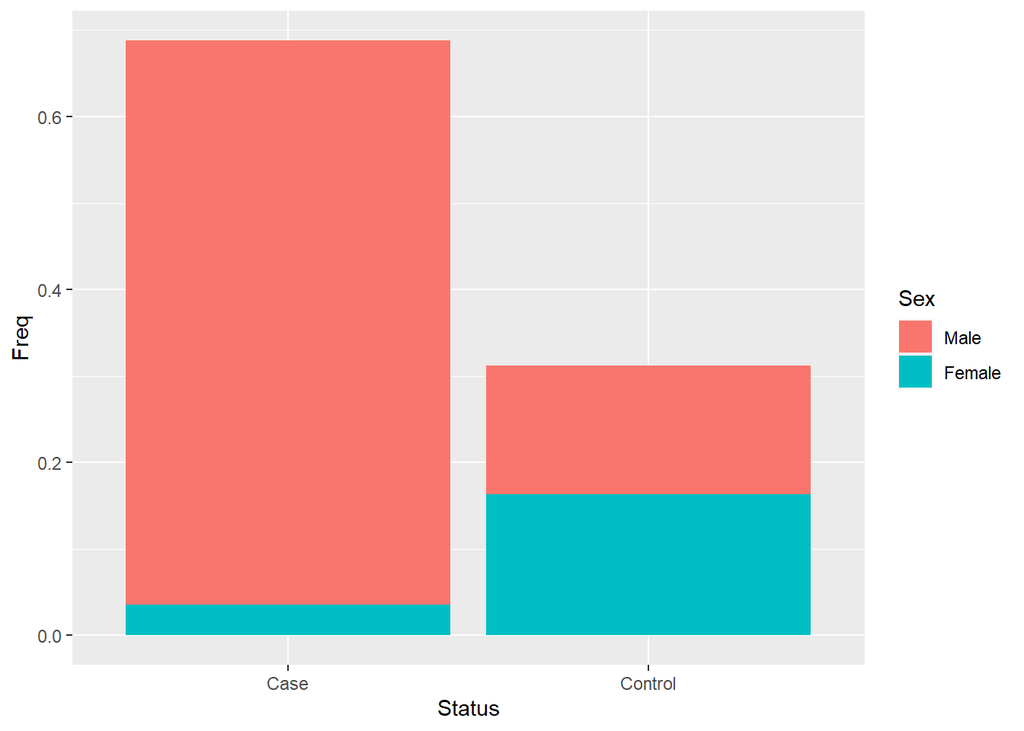

```r
tab <- as.data.frame(prop.table(table(bio2$STATUS, bio2$SEX)))

ggplot(tab, aes(x = Var1, y = Freq, fill=Var2)) + geom_col() + labs(x = "Status", fill = "Sex") +
  scale_x_discrete(breaks = c(1,2), labels = c("Case","Control")) +
  scale_fill_discrete(breaks = c(1,2), labels = c("Male","Female"))
```

- Status with Age: Cases are older.

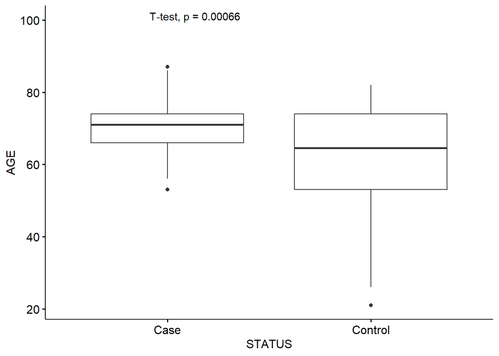

```r
ggboxplot(bio2, x = "STATUS", y = "AGE") +
  geom_boxplot() +
  stat_compare_means(method = "t.test", label.y = 100) +
  scale_x_discrete(breaks = c(1,2), labels = c("Case","Control"))
```

- Status with Smoking: There are less smokers in controls.

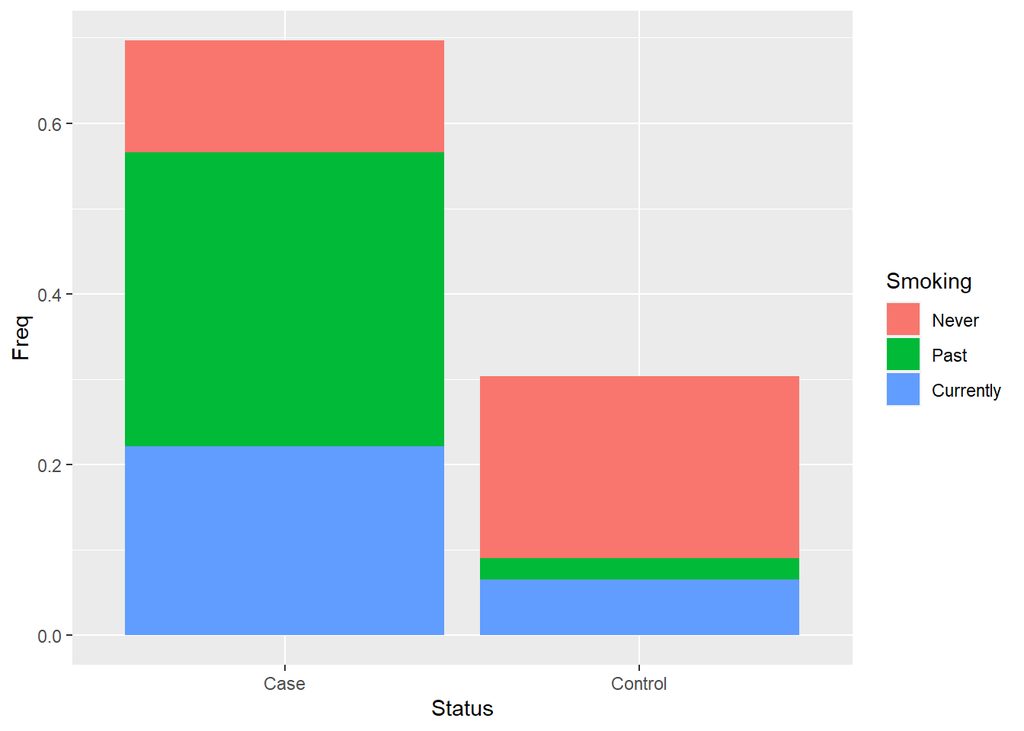

```r
tab <- as.data.frame(prop.table(table(bio2$STATUS, bio2$SMOKING)))

ggplot(tab, aes(x = Var1, y = Freq, fill=Var2)) + geom_col() + labs(x = "Status", fill = "Smoking") +
  scale_x_discrete(breaks = c("1","2"), labels = c("Case","Control")) +
  scale_fill_discrete(breaks = c(0,1,2), labels = c("Never","Past","Currently"))
```

- Sex with Smoking: There are more smokers among men (There are more cases in men).

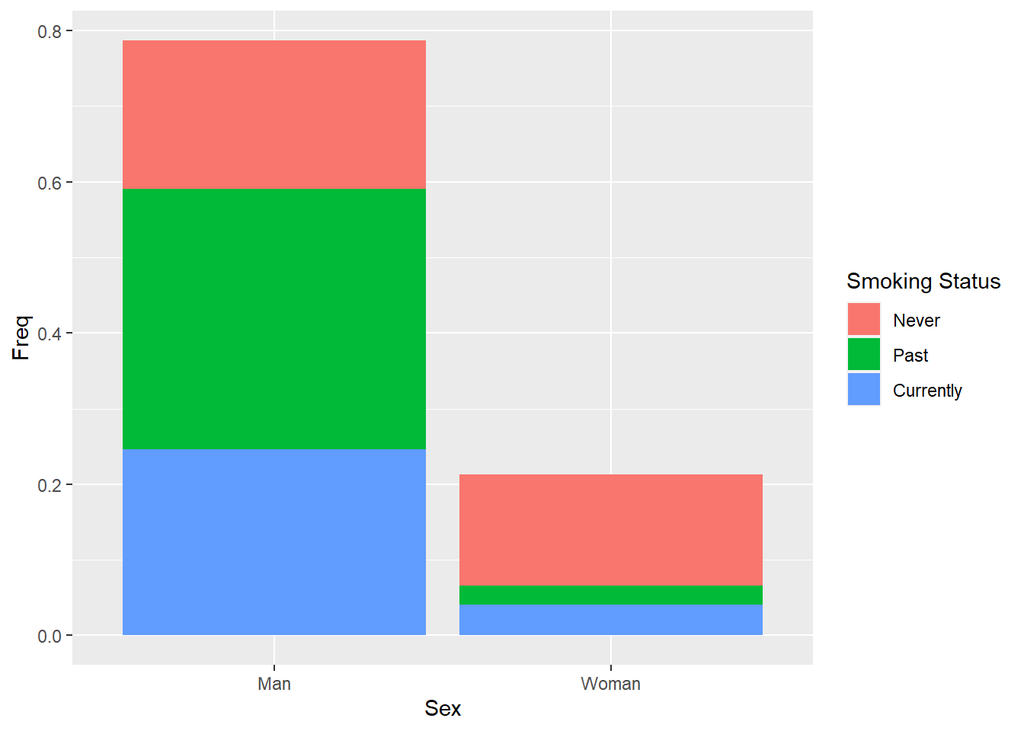

```r
tab <- as.data.frame(prop.table(table(bio2$SEX, bio2$SMOKING)))

ggplot(tab, aes(x = Var1, y = Freq, fill=Var2)) + geom_col() + labs(x = "Sex", fill = "Smoking Status") +
  scale_x_discrete(breaks = c("1","2"), labels = c("Man","Woman")) +
  scale_fill_discrete(breaks = c("0","1","2"), labels = c("Never","Past","Currently"))
```

- Age with Weight: Weight reduced with age.

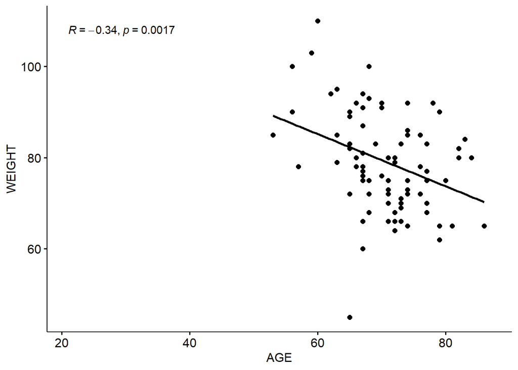

```r
ggscatter(bio2, x = "AGE", y = "WEIGHT",
          add = "reg.line") +
  stat_cor(method = "pearson")
```

- Type of Aneurysm with Symptoms: There are more symptoms with Inflammatory aneurysms.

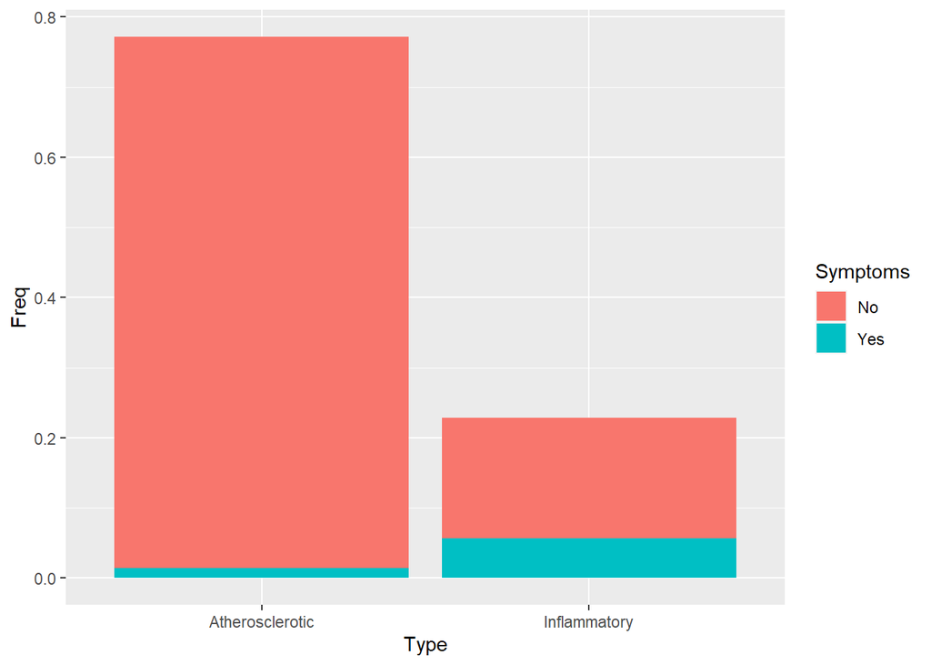

```r
tab <- as.data.frame(prop.table(table(bio2$TYPE, bio2$SYMPTOMS)))

ggplot(tab, aes(x = Var1, y = Freq, fill=Var2)) + geom_col() + labs(x = "Type", fill = "Symptoms") +
  scale_x_discrete(breaks = c("1","2"), labels = c("Atherosclerotic","Inflammatory")) +
  scale_fill_discrete(breaks = c("0","1"), labels = c("No", "Yes"))
```

- Type with Aortic Diameter: Inflammatory aneurysms have bigger diameters.

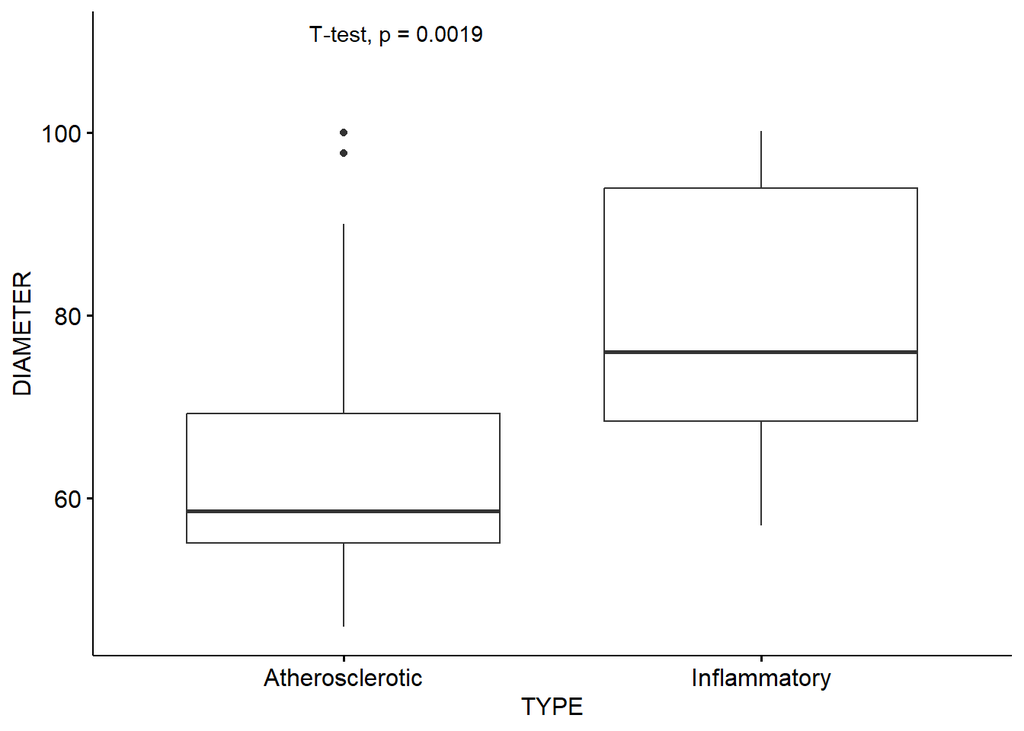

```r
ggboxplot(subset(bio2, !is.na(TYPE)), x = "TYPE", y = "DIAMETER") +
  geom_boxplot() +
  stat_compare_means(method = "t.test", label.y = 110) +
  scale_x_discrete(breaks = c(1,2), labels = c("Atherosclerotic","Inflammatory"))
```

- Symptoms with Smoking:

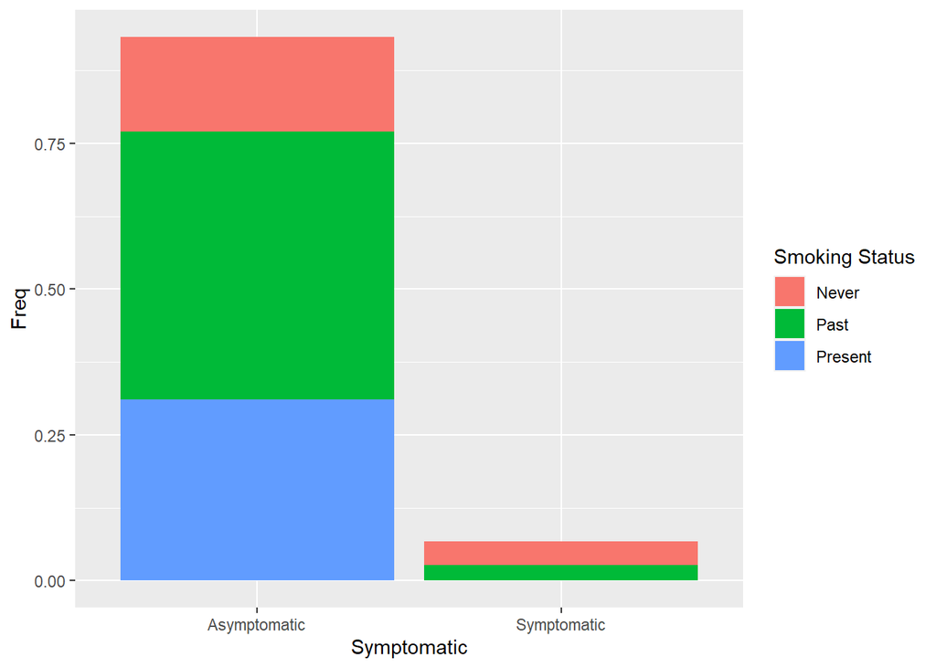

```r
tab <- as.data.frame(prop.table(table(bio2$SYMPTOMS, bio2$SMOKING)))

ggplot(tab, aes(x = Var1, y = Freq, fill=Var2)) + geom_col() + labs(x = "Symptomatic", fill = "Smoking Status") +
  scale_x_discrete(breaks = c("0","1"), labels = c("Asymptomatic","Symptomatic")) +
  scale_fill_discrete(breaks = c("0","1","2"),labels = c("Never", "Past", "Present"))
```

- Symptoms with Diameter: Symptomatic aneurysms are bigger.

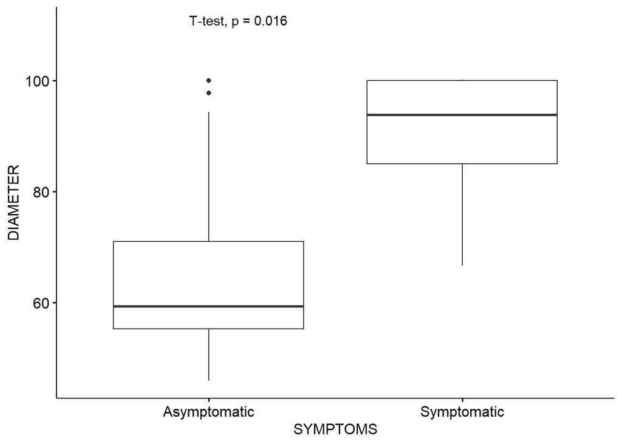

```r
ggboxplot(subset(bio2, !is.na(SYMPTOMS)), x = "SYMPTOMS", y = "DIAMETER") +
  geom_boxplot() +
  stat_compare_means(method = "t.test", label.y = 110) +
  scale_x_discrete(breaks = c(0,1), labels = c("Asymptomatic","Symptomatic"))
```

- Weight with Height.

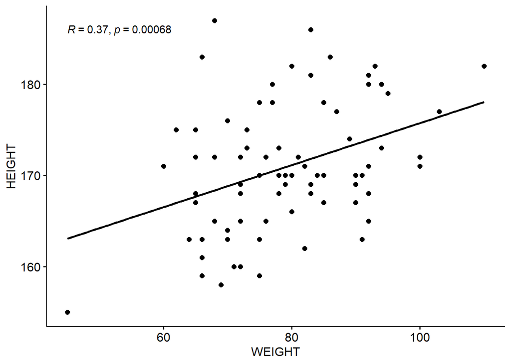

```r
ggscatter(bio2, x = "WEIGHT", y = "HEIGHT",
          add = "reg.line") +
  stat_cor(method = "pearson")
```

## CASES:

### Merge all covariates:

```r
all.cases <- merge(b.cases, t.cases, by = 0)
all.cases <- all.cases %>% remove_rownames %>% column_to_rownames(var="Row.names")
```

```r
# Remove columns that have no variation:
all.cases <-  all.cases[ ,!names(all.cases) %in% c("STATUS","FC")]
```

```r
M <- cor(all.cases, use = "pairwise.complete.obs")
testRes <- cor.mtest(all.cases, conf.level = 0.95)

M[is.na(M)] <- 0
testRes$p[is.na(testRes$p)] <- 1

png(file = "C://Users/Gerard/Desktop/AAA/RNAseq/Plots/Correlations/Correlation_Plot_Cases.png", height = 10000, width = 10000, res = 1200)
corrplot(M, p.mat = testRes$p, sig.level = 0.05, type = "lower", insig = "blank")
dev.off()
```

```r
#corrplot(M, p.mat = testRes$p, sig.level = 0.05, type = "lower", insig = "blank")
```

```r
# Filter only biological samples:
filter.cases <-  all.cases[ ,c("SEX","AGE","TYPE","SYMPTOMS","HEIGHT","WEIGHT","SMOKING","O.ANEURYSM","DIAMETER")]
```

```r
M <- cor(filter.cases, use = "pairwise.complete.obs")
testRes <- cor.mtest(filter.cases, conf.level = 0.95)

M[is.na(M)] <- 0
testRes$p[is.na(testRes$p)] <- 1

png(file = "C://Users/Gerard/Desktop/AAA/RNAseq/Plots/Correlations/Correlation_Plot_Cases_Biological.png", height = 10000, width = 10000, res = 1200)
corrplot(M, p.mat = testRes$p, sig.level = 0.05, type = "lower", insig = "blank", tl.cex = 2)
dev.off()
```

```r
#corrplot(M, p.mat = testRes$p, sig.level = 0.05, type = "lower", insig = "blank")
```

- Age with Weight: Weight reduces with age.

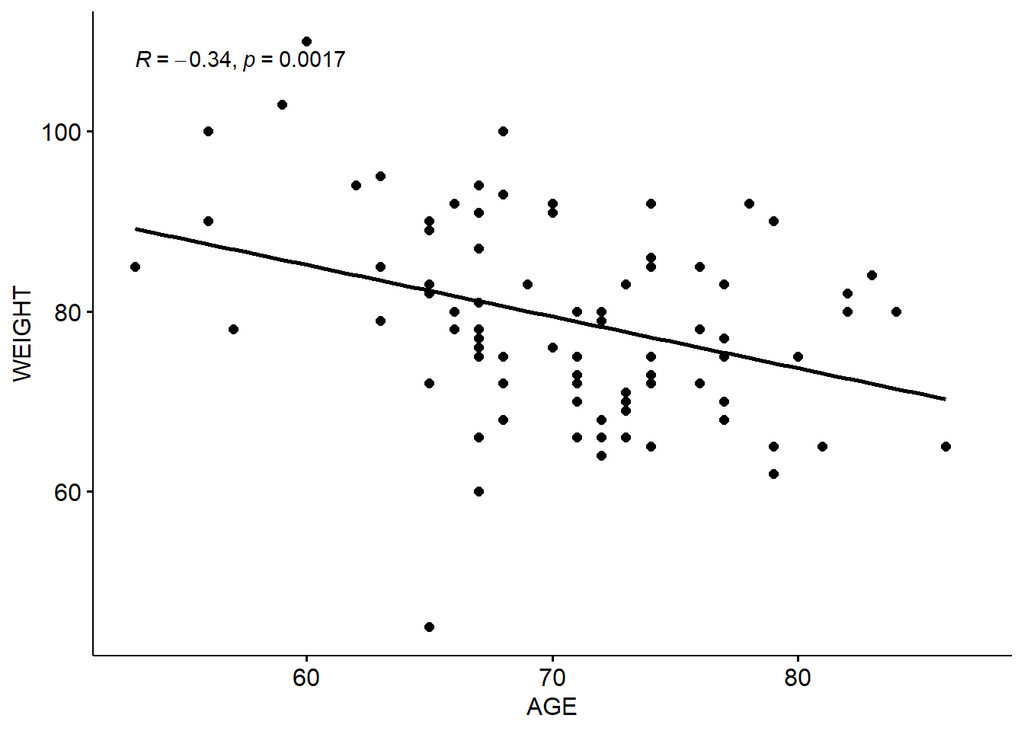

```r
ggscatter(b.cases, x = "AGE", y = "WEIGHT",
          add = "reg.line") +
  stat_cor(method = "pearson")
```

- Age with Smoking: Currently smokers are younger.

[output not shown]

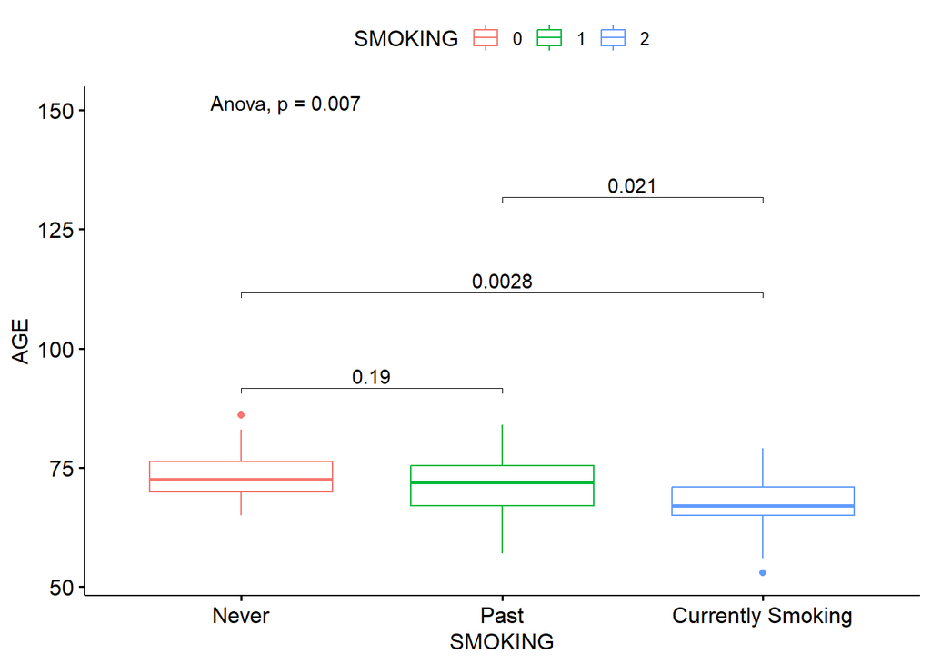

```r
my_comparisons <- list( c("0","1"), c("0", "2"), c("1", "2") )

ggboxplot(subset(b.cases, !is.na(SMOKING)), x = "SMOKING", y = "AGE", color = "SMOKING") +
  stat_compare_means(comparisons = my_comparisons, label.y = c(90, 110, 130), method = "t.test") +
  stat_compare_means(label.y = c(150), method = "anova") +
  scale_x_discrete(breaks = c("0","1","2"), labels = c("Never","Past","Currently Smoking"))
```

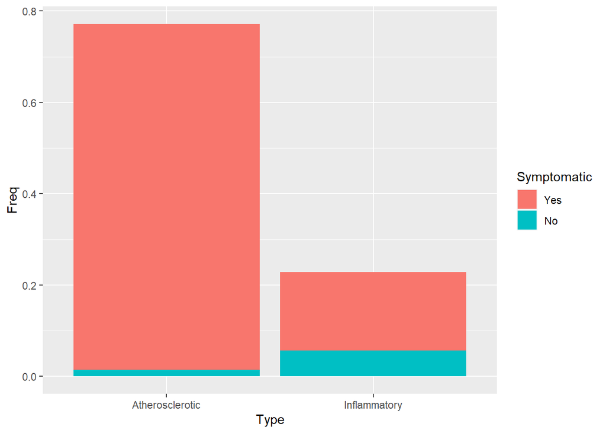

```r
tab <- as.data.frame(prop.table(table(b.cases$SYMPTOMS, b.cases$TYPE)))

ggplot(tab, aes(x = Var2, y = Freq, fill=Var1)) + geom_col() + labs(fill = "Symptomatic", x = "Type") +
  scale_fill_discrete(labels = c("Yes", "No")) +
  scale_x_discrete(labels = c("Atherosclerotic","Inflammatory"))
```

- Type of Aneurysm with Diameter: Inflammatory aneurysms are bigger.

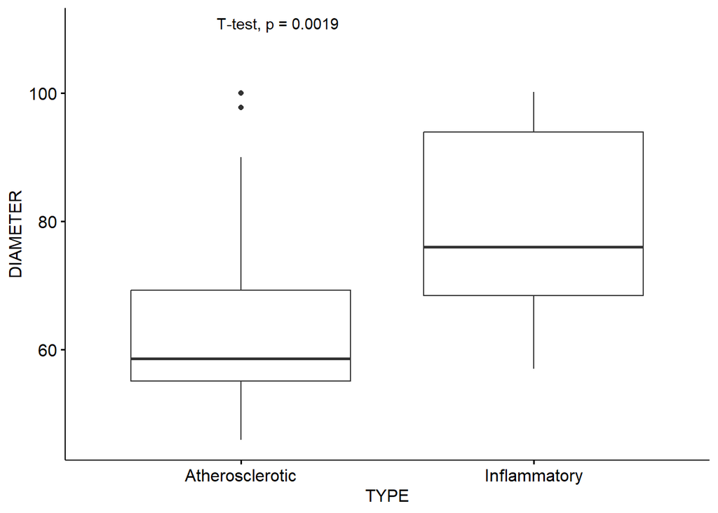

```r
ggboxplot(subset(b.cases, !is.na(TYPE)), x = "TYPE", y = "DIAMETER") +
  geom_boxplot() +
  stat_compare_means(method = "t.test", label.y = 110) +
  scale_x_discrete(breaks = c(1,2), labels = c("Atherosclerotic","Inflammatory"))
```

- Symptoms with Smoking:

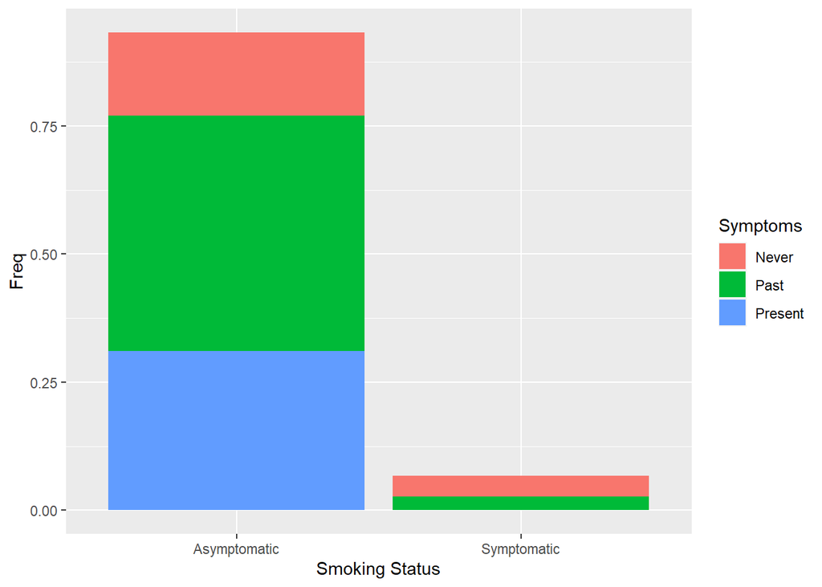

```r
tab <- as.data.frame(prop.table(table(b.cases$SYMPTOMS, b.cases$SMOKING)))

ggplot(tab, aes(x = Var1, y = Freq, fill=Var2)) + geom_col() + labs(x = "Smoking Status", fill = "Symptoms") +
  scale_x_discrete(breaks = c("0","1"), labels = c("Asymptomatic","Symptomatic")) +
  scale_fill_discrete(breaks = c("0","1","2"),labels = c("Never", "Past", "Present"))
```

- Symptoms with Diameter: Symptomatic aneurysms are bigger.

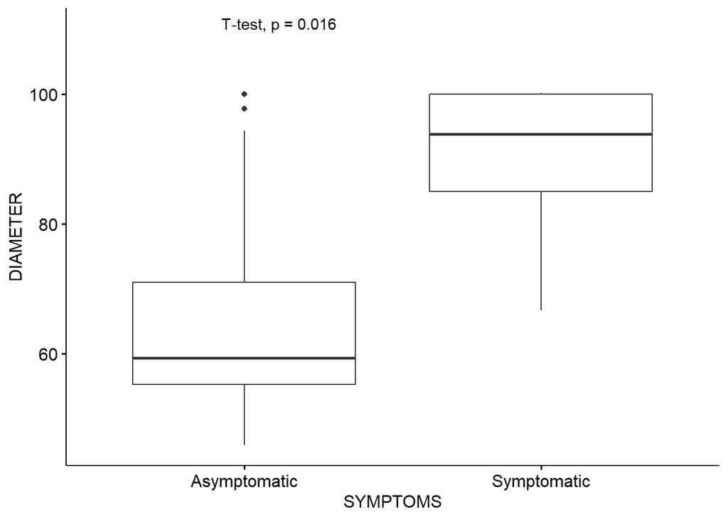

```r
ggboxplot(subset(b.cases, !is.na(SYMPTOMS)), x = "SYMPTOMS", y = "DIAMETER") +
  geom_boxplot() +
  stat_compare_means(method = "t.test", label.y = 110) +
  scale_x_discrete(breaks = c(0,1), labels = c("Asymptomatic","Symptomatic"))
```

- Height with Weight.

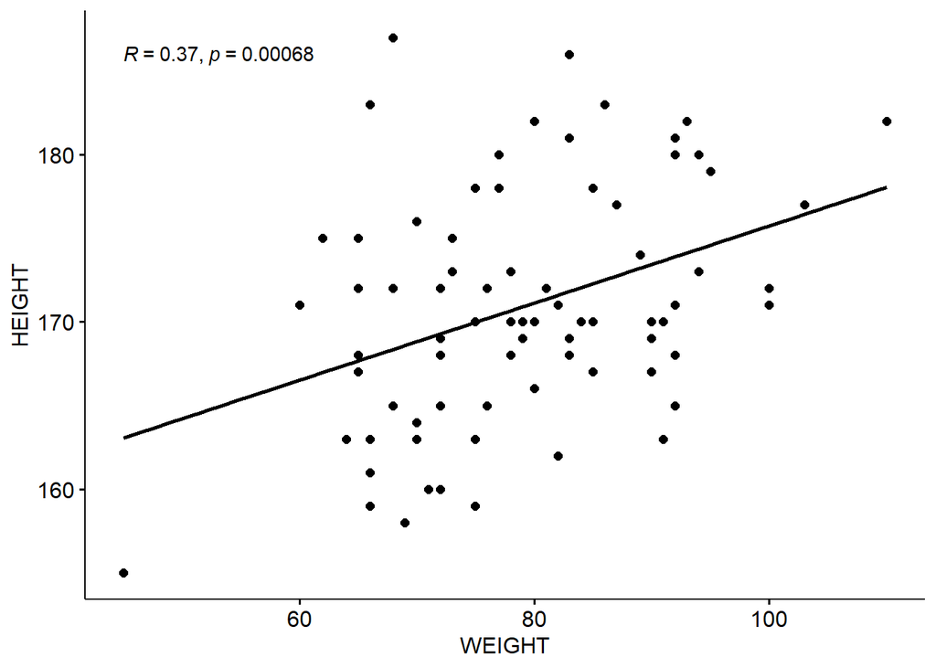

```r
ggscatter(b.cases, x = "WEIGHT", y = "HEIGHT",
          add = "reg.line") +
  stat_cor(method = "pearson")
```

## CONTROLS:

### Merge all covariates:

```r
all.controls <- merge(b.controls, t.controls, by = 0)
all.controls <- all.controls %>% remove_rownames %>% column_to_rownames(var="Row.names")
```

```r
# Remove columns that have no variation:
all.controls <-  all.controls[ ,!names(all.controls) %in% c("STATUS","TYPE","SYMPTOMS","HEIGHT","WEIGHT","O.ANEURYSM","DIAMETER")]
```

```r
M <- cor(all.controls, use = "pairwise.complete.obs")
testRes <- cor.mtest(all.controls, conf.level = 0.95)

M[is.na(M)] <- 0
testRes$p[is.na(testRes$p)] <- 1

png(file = "C://Users/Gerard/Desktop/AAA/RNAseq/Plots/Correlations/Correlation_Plot_Controls.png")
corrplot(M, p.mat = testRes$p, sig.level = 0.05, type = "lower", insig = "blank", tl.cex = 2)
dev.off()
```

```r
#corrplot(M, p.mat = testRes$p, sig.level = 0.05, type = "lower", insig = "blank", tl.cex = 2)
```